# Rally 6A Study Inventory

Andrew Mertens

February 13, 2018

## List of studies on GHAP from INDIA

- Mal-ED - India Cohort
- COHORTS - India Cohort
- ki1000301 - DIVIDS
- ki1000108 - IRC
- ki1000108 - TDC
- ki1000108 - CMC-V-BCS-2002
- ki1000304 - VITAMIN-A
- ki1000304 - NEOVITA
- ki1000304 - Vitamin-B12
- ki1000304 - ZnMort
- ki1000304 - EU
- ki1000304 - LBW
- ki1000304b - SAS-FoodSuppl
- ki1000304b - SAS-CompFeed
- ki1000304b - ZincInf
- ki1000304c - IMNCI
- ki1000302 - TTBW
- ki1000306 - ZincSGA
- ki1000303 - BtS
- ki1000303 - NBSP
- ki1000305 - CordBloodCytometry
- GEMS-1
- GEMS-1A
- ANISA
- DSS
- MAHANTrust

### Study exclusion

Drop cross-sectional studies and studies without longitudinal anthropometry data

```
## [1] "TTBW"               "NBSP"               NA
## [4] "IMNCI"              "CordBloodCytometry" "GEMS-1"
## [7] "GEMS-1A"            "ANISA"              "DSS"
```

Drop studies without anthropometry

```
## [1] "NEOVITA"    "NEOVITA"    "MAHANTrust"
```

Drop studies only measuring children older than 2 years

```
## [1] "BTS"
```

### Study descriptions

List descriptions of longitudinal studies with anthropometry data from India:

| study_id | short_description |
| --- | --- |
| CMC-V-BCS-2002 | CMC Vellore Birth Cohort 2002 |
| COHORTS | COHORTS |
| DIVIDS | DIVIDS-1 with 5 year Follow-up |
| EU | Zn Supp for Diarrheal Pneuomonia |
| IRC | Vellore Crypto Study |
| LBW | Zn Supp Trial in LBW |
| MAL-ED | MAL-ED Study (PMID25305287) |
| SAS-CompFeed | Optimal Infant Feeding Practices |
| SAS-FoodSuppl | Randomized Food Supplementation Trial Ages 4-12 Months |
| TDC | Transmission Dynamics of Cryptosporidial Infections |
| VITAMIN-A | EPI Linked Vita A |
| ZincInf | Zn Treatment for Diarrhea |
| ZnMort | Zn Supp and Infant Mortality |

Note that the ZincSGA (“Zinc supplementation in infants born small for gestational age”) and Vitamin B12 (“Vitamin B12 supplementation”) seem to be missing from the get_sudylist_anthro() metadata list

Note that the following studies enrol acutely ill children:

- ZincSGA -small for gestational age
- DIVIDS -low birth weight
- LBW -low birth weight
- ZincInf -children with diarrhea

The followinmg studies did not start measurement at birth and therefore misses a key risk period for wasting / stunting.

- ki1000304 -EU (6 months)
- ki1000304b -SAS-FoodSuppl (4 months)
- ki1000304 -Vitamin-B12 (6 months)
- ki1000304b -ZincInf (anytime between 1-5 months)
- ki100030 -ZnMort (anytime between 1-23 months)

### Heatmap of number of observations per month of child age by study

Heatmap displays number of observations within each childage in months for each study with longitudinal anthropometry data for the first 48 months (4 years) of a child’s life.

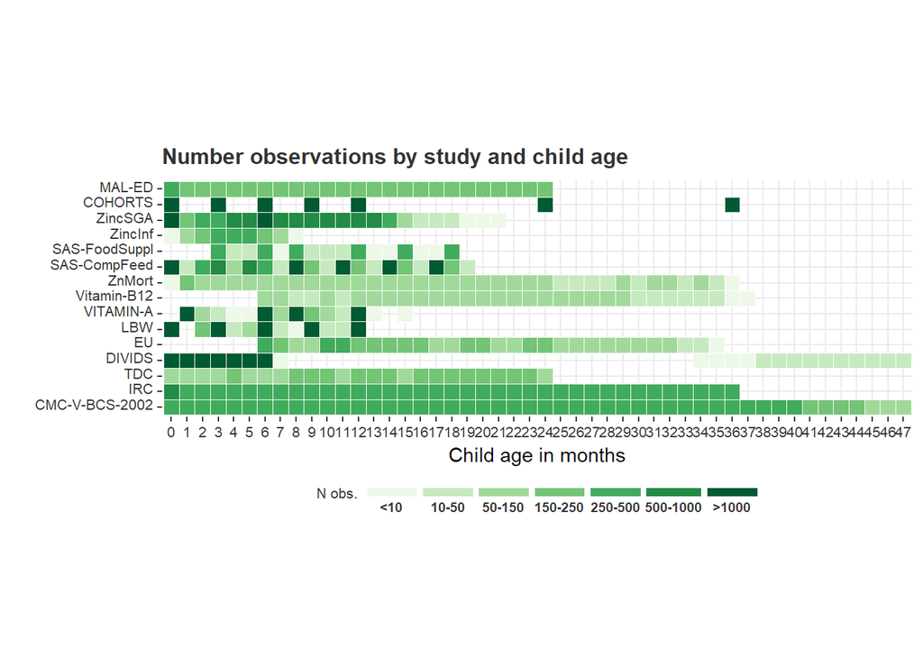

### Heatmap of mean WHZ

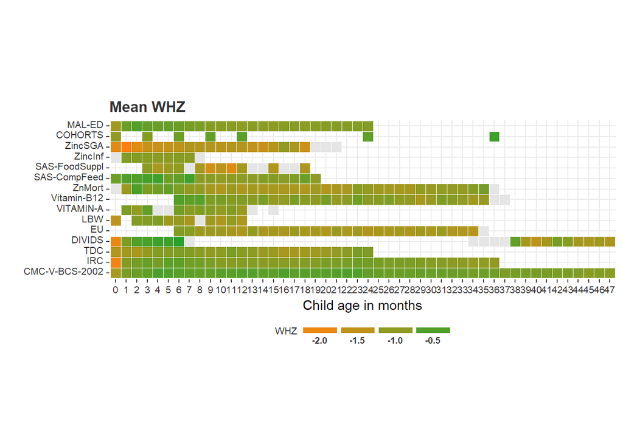

Cells are colored grey is there are less than 10 observations in a cell. Note smaller mean WHZ early in children’s lives.

### Heatmap of mean HAZ

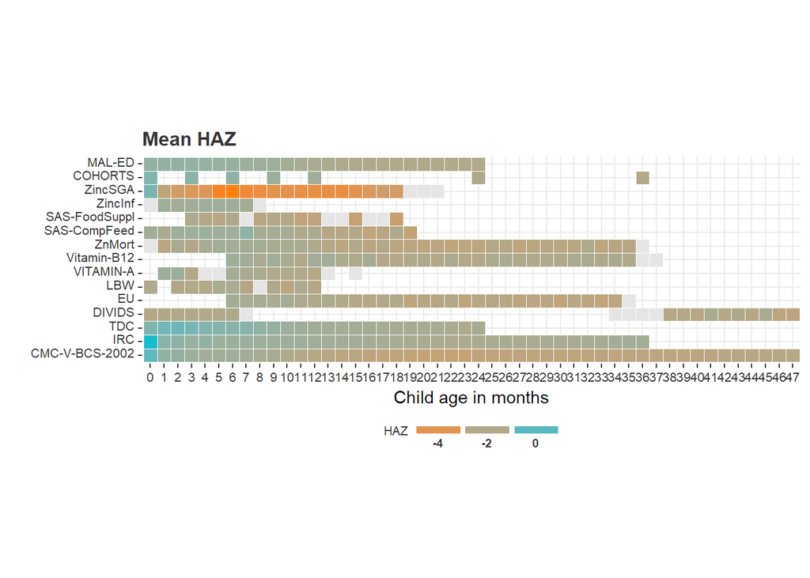

Note smaller mean HAZ as the child approaches 2 years in age.

### Heatmap of wasting prevalence

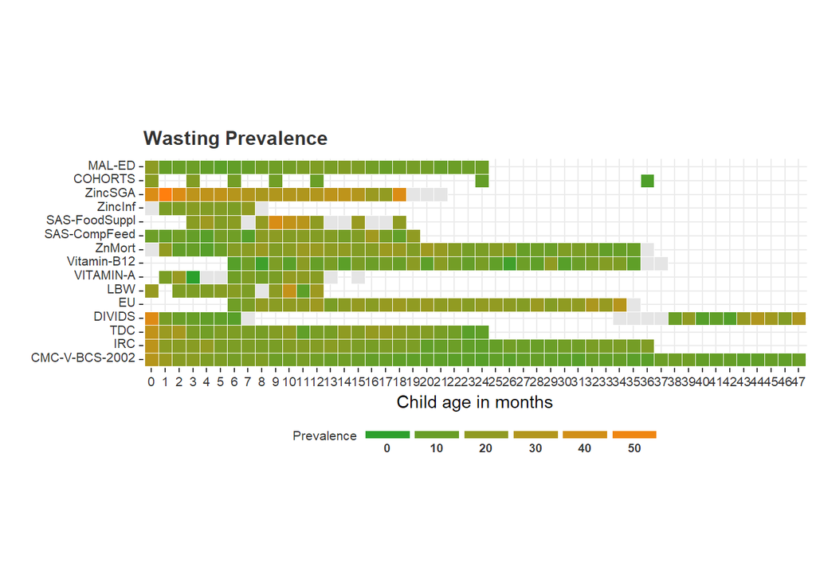

Earlier peak in wasting prevalence

### Heatmap of stunting prevalence

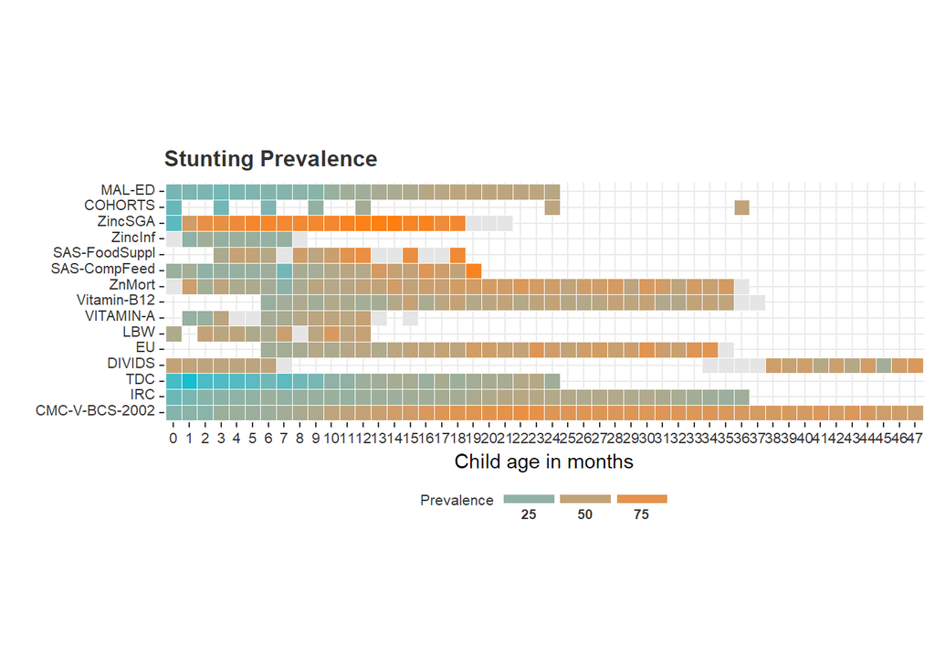

Increased faltering to stunting as the child ages.

### Heatmap of severe wasting prevalence

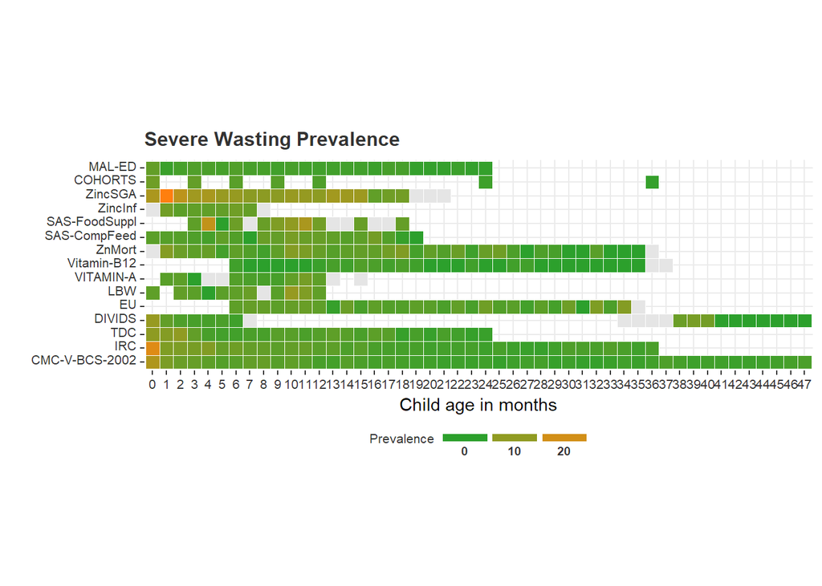

### Heatmap of severe stunting prevalence

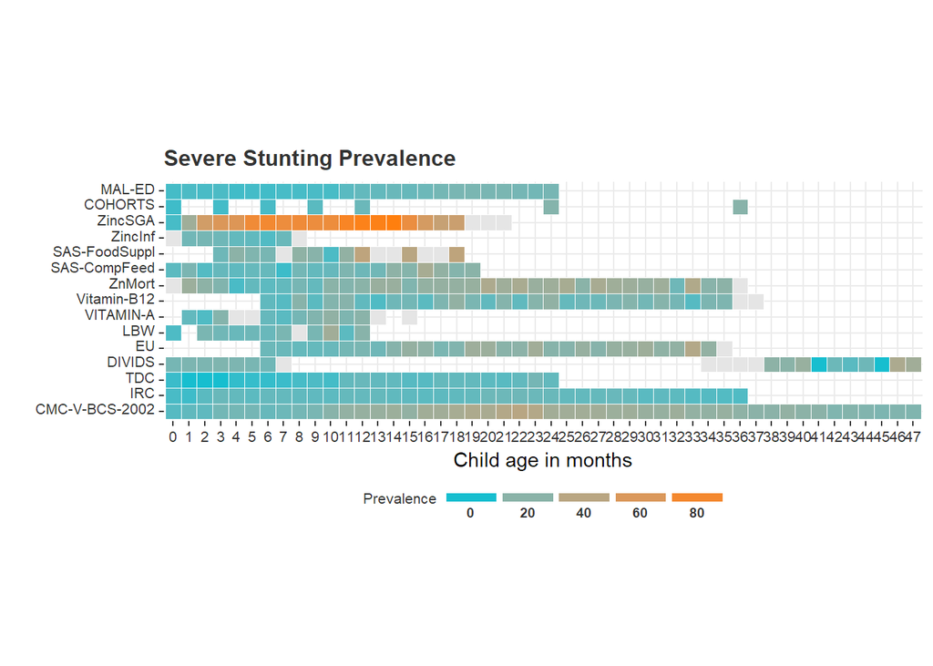

Much more severe stunting int ZincSGA, a study that enrolled small for gestational age infants. There doesn not appear to be catch-up growth on average in these children.